# Bakery Analysis

Rica Rebusit

2023-10-29

I will be using this dataset from Kaggle ->

[figure not shown]

to analyze and forecast sales of a french bakery from 2021 to 2022 based on:

date: Date order time: Time order ticket number: Identifier for every single transaction article: Name of the product sold quantity: quantity sold unit_price: price per product (In Euros)

There are 234,005 observations in the dataset as well.

# Loading Necessary Libraries and Importing Data

```r
library(tidyverse)
library(gridExtra)
bakery <- read.csv("Bakery sales.csv")
```

# EDA and Data Cleaning

```r
head(bakery)
```

|  | X | date | time | ticket_number | article | Quantity | unit_price |
| --- | --- | --- | --- | --- | --- | --- | --- |
| 1 | 0 | 2021-01-02 | 08:38 | 150040 | BAGUETTE | 1 | 0,90 € |
| 2 | 1 | 2021-01-02 | 08:38 | 150040 | PAIN AU CHOCOLAT | 3 | 1,20 € |
| 3 | 4 | 2021-01-02 | 09:14 | 150041 | PAIN AU CHOCOLAT | 2 | 1,20 € |
| 4 | 5 | 2021-01-02 | 09:14 | 150041 | PAIN | 1 | 1,15 € |
| 5 | 8 | 2021-01-02 | 09:25 | 150042 | TRADITIONAL BAGUETTE | 5 | 1,20 € |
| 6 | 11 | 2021-01-02 | 09:25 | 150043 | BAGUETTE | 2 | 0,90 € |

```r
str(bakery)
```

```
## 'data.frame':    234005 obs. of  7 variables:
##  $ X            : int  0 1 4 5 8 11 12 15 18 19 ...
##  $ date         : chr  "2021-01-02" "2021-01-02" "2021-01-02" "2021-01-02" ...
##  $ time         : chr  "08:38" "08:38" "09:14" "09:14" ...
##  $ ticket_number: num  150040 150040 150041 150041 150042 ...
##  $ article      : chr  "BAGUETTE" "PAIN AU CHOCOLAT" "PAIN AU CHOCOLAT" "PAIN" ...
##  $ Quantity     : num  1 3 2 1 5 2 3 1 3 6 ...
##  $ unit_price   : chr  "0,90 €" "1,20 €" "1,20 €" "1,15 €" ...
```

Checking for missing values

```r
sum(is.na(bakery))
```

```
## [1] 0
```

```r
#No missing values
```

Checking for duplicated rows

```r
sum(duplicated(bakery))
```

```
## [1] 0
```

```r
#No duplicated rows
```

Cleaning up variable names

```r
bakery <- select(bakery, -("X")) %>% #Dropping unnecessary column
  rename(quantity = Quantity) #Rename column Quantity with a lowercase q to keep variable uniformity
head(bakery)
```

|  | date | time | ticket_number | article | quantity | unit_price |
| --- | --- | --- | --- | --- | --- | --- |
| 1 | 2021-01-02 | 08:38 | 150040 | BAGUETTE | 1 | 0,90 € |
| 2 | 2021-01-02 | 08:38 | 150040 | PAIN AU CHOCOLAT | 3 | 1,20 € |
| 3 | 2021-01-02 | 09:14 | 150041 | PAIN AU CHOCOLAT | 2 | 1,20 € |
| 4 | 2021-01-02 | 09:14 | 150041 | PAIN | 1 | 1,15 € |
| 5 | 2021-01-02 | 09:25 | 150042 | TRADITIONAL BAGUETTE | 5 | 1,20 € |
| 6 | 2021-01-02 | 09:25 | 150043 | BAGUETTE | 2 | 0,90 € |

Convert *unit_price* to numeric for analysis and sale forecasting. First getting rid of Euro symbol and replacing comma with a period

```r
bakery$unit_price <- gsub(" €", " ", bakery$unit_price) #Replaces Euro with empty space
bakery$unit_price <- gsub(",", ".", bakery$unit_price) #Replaces comma with period
head(bakery)
```

|  | date | time | ticket_number | article | quantity | unit_price |
| --- | --- | --- | --- | --- | --- | --- |
| 1 | 2021-01-02 | 08:38 | 150040 | BAGUETTE | 1 | 0.90 |
| 2 | 2021-01-02 | 08:38 | 150040 | PAIN AU CHOCOLAT | 3 | 1.20 |
| 3 | 2021-01-02 | 09:14 | 150041 | PAIN AU CHOCOLAT | 2 | 1.20 |
| 4 | 2021-01-02 | 09:14 | 150041 | PAIN | 1 | 1.15 |
| 5 | 2021-01-02 | 09:25 | 150042 | TRADITIONAL BAGUETTE | 5 | 1.20 |
| 6 | 2021-01-02 | 09:25 | 150043 | BAGUETTE | 2 | 0.90 |

Now we can convert *unit_price* to numeric

```r
bakery$unit_price <- as.numeric(bakery$unit_price)
head(bakery)
```

|  | date | time | ticket_number | article | quantity | unit_price |
| --- | --- | --- | --- | --- | --- | --- |
| 1 | 2021-01-02 | 08:38 | 150040 | BAGUETTE | 1 | 0.90 |
| 2 | 2021-01-02 | 08:38 | 150040 | PAIN AU CHOCOLAT | 3 | 1.20 |
| 3 | 2021-01-02 | 09:14 | 150041 | PAIN AU CHOCOLAT | 2 | 1.20 |
| 4 | 2021-01-02 | 09:14 | 150041 | PAIN | 1 | 1.15 |
| 5 | 2021-01-02 | 09:25 | 150042 | TRADITIONAL BAGUETTE | 5 | 1.20 |
| 6 | 2021-01-02 | 09:25 | 150043 | BAGUETTE | 2 | 0.90 |

Calculating total of each purchase

```r
bakery <- mutate(bakery, total = unit_price * quantity) #Mutate creates a new column
head(bakery)
```

|  | date | time | ticket_number | article | quantity | unit_price | total |
| --- | --- | --- | --- | --- | --- | --- | --- |
| 1 | 2021-01-02 | 08:38 | 150040 | BAGUETTE | 1 | 0.90 | 0.90 |
| 2 | 2021-01-02 | 08:38 | 150040 | PAIN AU CHOCOLAT | 3 | 1.20 | 3.60 |
| 3 | 2021-01-02 | 09:14 | 150041 | PAIN AU CHOCOLAT | 2 | 1.20 | 2.40 |
| 4 | 2021-01-02 | 09:14 | 150041 | PAIN | 1 | 1.15 | 1.15 |
| 5 | 2021-01-02 | 09:25 | 150042 | TRADITIONAL BAGUETTE | 5 | 1.20 | 6.00 |
| 6 | 2021-01-02 | 09:25 | 150043 | BAGUETTE | 2 | 0.90 | 1.80 |

For analysis, creating columns that separate date into year, month, day, and day name

```r
bakery$date <- as.Date(bakery$date)
bakery <- mutate(bakery,
    year = format(bakery$date, "%Y"),
    month = format(bakery$date, "%m"),
    day = format(bakery$date, "%d"),
    day_name = format(bakery$date, "%A"))
head(bakery)
```

|  | date | time | ticket_number | article | quantity | unit_price | total | year | month | day | day_name |
| --- | --- | --- | --- | --- | --- | --- | --- | --- | --- | --- | --- |
| 1 | 2021-01-02 | 08:38 | 150040 | BAGUETTE | 1 | 0.90 | 0.90 | 2021 | 01 | 02 | Saturday |
| 2 | 2021-01-02 | 08:38 | 150040 | PAIN AU CHOCOLAT | 3 | 1.20 | 3.60 | 2021 | 01 | 02 | Saturday |
| 3 | 2021-01-02 | 09:14 | 150041 | PAIN AU CHOCOLAT | 2 | 1.20 | 2.40 | 2021 | 01 | 02 | Saturday |
| 4 | 2021-01-02 | 09:14 | 150041 | PAIN | 1 | 1.15 | 1.15 | 2021 | 01 | 02 | Saturday |
| 5 | 2021-01-02 | 09:25 | 150042 | TRADITIONAL BAGUETTE | 5 | 1.20 | 6.00 | 2021 | 01 | 02 | Saturday |
| 6 | 2021-01-02 | 09:25 | 150043 | BAGUETTE | 2 | 0.90 | 1.80 | 2021 | 01 | 02 | Saturday |

Checking for outliers

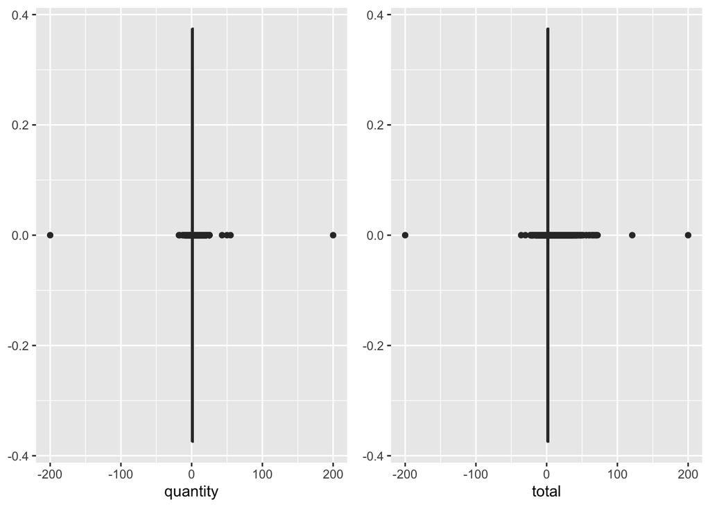

```r
grid.arrange(
  ggplot(bakery, aes(quantity)) + geom_boxplot(),
  ggplot(bakery, aes(total)) + geom_boxplot(),
  ncol = 2
)
```

It seems there is a negative value for qunatity and total, needs to be dropped

```r
bakery <- filter(bakery, !(quantity <= 0 | total <= 0))
head(bakery)
```

|  | date | time | ticket_number | article | quantity | unit_price | total | year | month | day | day_name |
| --- | --- | --- | --- | --- | --- | --- | --- | --- | --- | --- | --- |
| 1 | 2021-01-02 | 08:38 | 150040 | BAGUETTE | 1 | 0.90 | 0.90 | 2021 | 01 | 02 | Saturday |
| 2 | 2021-01-02 | 08:38 | 150040 | PAIN AU CHOCOLAT | 3 | 1.20 | 3.60 | 2021 | 01 | 02 | Saturday |
| 3 | 2021-01-02 | 09:14 | 150041 | PAIN AU CHOCOLAT | 2 | 1.20 | 2.40 | 2021 | 01 | 02 | Saturday |
| 4 | 2021-01-02 | 09:14 | 150041 | PAIN | 1 | 1.15 | 1.15 | 2021 | 01 | 02 | Saturday |
| 5 | 2021-01-02 | 09:25 | 150042 | TRADITIONAL BAGUETTE | 5 | 1.20 | 6.00 | 2021 | 01 | 02 | Saturday |
| 6 | 2021-01-02 | 09:25 | 150043 | BAGUETTE | 2 | 0.90 | 1.80 | 2021 | 01 | 02 | Saturday |

Since the dataset provides years 2021 and 2022, let’s look at total in both years

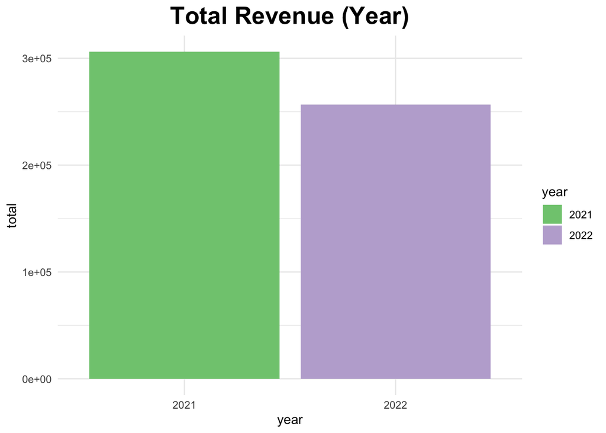

```r
ggplot(bakery, aes(year, total, fill = year)) + geom_bar(stat = "Identity") + theme_minimal() + scale_fill_brewer(palette = "Accent") + labs(title = "Total Revenue (Year)") + theme(plot.title = element_text(size = 20, face = "bold", hjust = 0.5))
```

In months

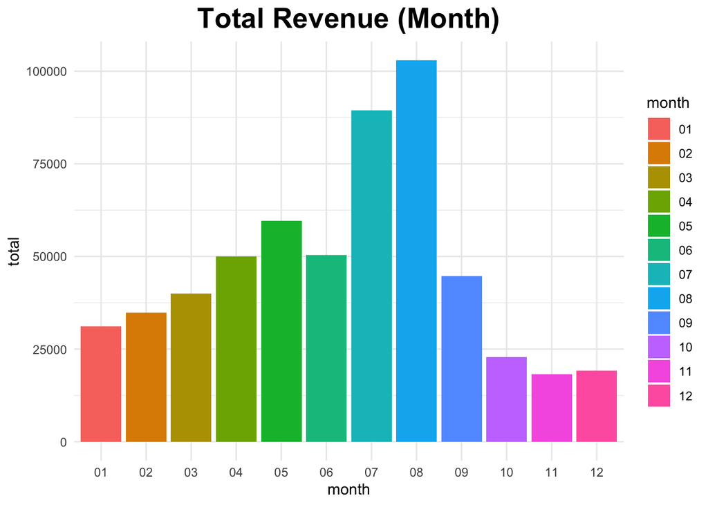

```r
ggplot(bakery, aes(month, total, fill = month)) + geom_bar(stat = "Identity") + theme_minimal() + labs(title = "Total Revenue (Month)") + theme(plot.title = element_text(size = 20, face = "bold", hjust = 0.5))
```

In days

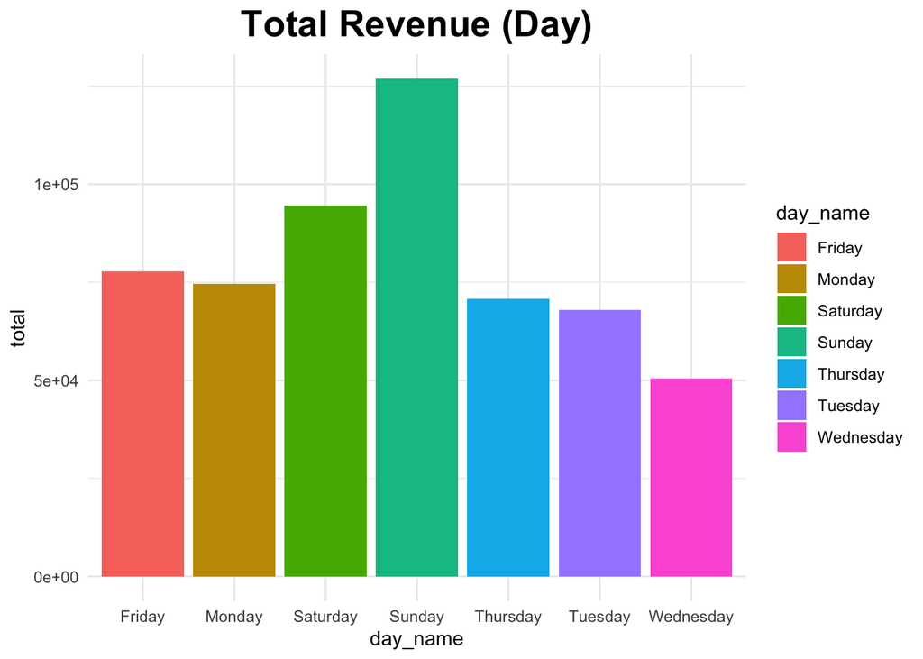

```r
ggplot(bakery, aes(day_name, total, fill = day_name)) + geom_bar(stat = "Identity") + theme_minimal() + labs(title = "Total Revenue (Day)") + theme(plot.title = element_text(size = 20, face = "bold", hjust = 0.5))
```

Comparing total revenue of both years

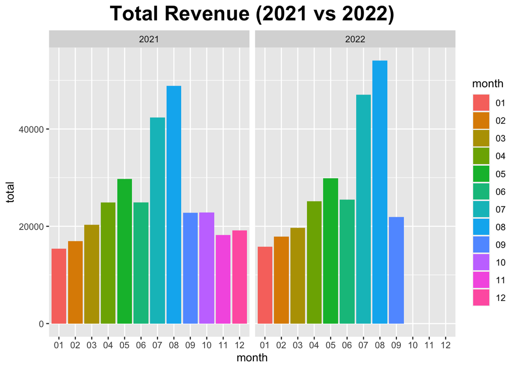

```r
ggplot(bakery, aes(month, total, fill = month)) + geom_bar(stat = "Identity") + facet_wrap(~ year) + labs(title = "Total Revenue (2021 vs 2022)") + theme(plot.title = element_text(size = 20, face = "bold", hjust = 0.5))
```

Looking at products in the bakery

```r
unique(bakery$article)
```

```
##   [1] "BAGUETTE"                 "PAIN AU CHOCOLAT"
##   [3] "PAIN"                     "TRADITIONAL BAGUETTE"
##   [5] "CROISSANT"                "BANETTE"
##   [7] "BANETTINE"                "SPECIAL BREAD"
##   [9] "COUPE"                    "SAND JB EMMENTAL"
##  [11] "KOUIGN AMANN"             "BOULE 200G"
##  [13] "BOULE 400G"               "GAL FRANGIPANE 6P"
##  [15] "CAMPAGNE"                 "MOISSON"
##  [17] "CAFE OU EAU"              "BRIOCHE"
##  [19] "CEREAL BAGUETTE"          "SEIGLE"
##  [21] "COMPLET"                  "GAL FRANGIPANE 4P"
##  [23] "COOKIE"                   "FICELLE"
##  [25] "PAIN AUX RAISINS"         "GAL POMME 6P"
##  [27] "GAL POMME 4P"             "FINANCIER X5"
##  [29] "VIK BREAD"                "DIVERS VIENNOISERIE"
```

[output cut: 59 more lines]

Which are the top 10 products?

```r
top10 <- bakery %>%
  group_by(article) %>%
  summarise(total = sum(total)) %>%
  arrange(desc(total)) %>%
  head(10)
top10
```

| article | total |
| --- | --- |
| TRADITIONAL BAGUETTE | 145533.75 |
| FORMULE SANDWICH | 35419.50 |
| CROISSANT | 33770.45 |
| PAIN AU CHOCOLAT | 31262.15 |
| BANETTE | 24704.30 |
| BAGUETTE | 20578.20 |
| SANDWICH COMPLET | 13659.50 |
| SPECIAL BREAD | 13498.60 |
| TRAITEUR | 12368.40 |
| GRAND FAR BRETON | 10786.00 |

Looking at total from top 10

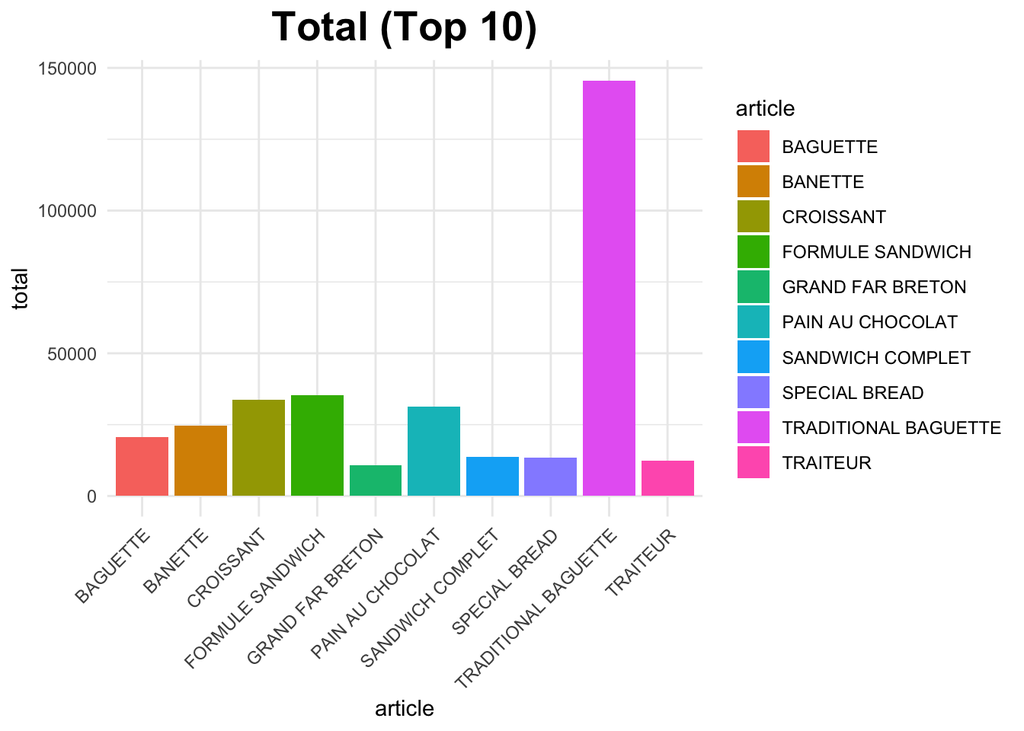

```r
ggplot(top10, aes(article, total, fill = article)) + geom_bar(stat = "Identity") + theme_minimal() + theme(axis.text.x = element_text(angle = 45, vjust = 1, hjust = 1)) + labs(title = "Total (Top 10)") + theme(plot.title = element_text(size = 20, face = "bold", hjust = 0.5))
```

Which are the bottom 10 products?

```r
bottom10 <- bakery %>%
  group_by(article) %>%
  summarise(total = sum(total)) %>%
  arrange(total) %>%
  head(10)
bottom10
```

| article | total |
| --- | --- |
| PAIN NOIR | 0.6 |
| CAKE | 3.0 |
| DOUCEUR D HIVER | 3.0 |
| TROIS CHOCOLAT | 3.0 |
| SACHET DE VIENNOISERIE | 4.0 |
| PALMIER | 6.0 |
| PLATPREPARE6,00 | 6.0 |
| TARTELETTE COCKTAIL | 6.0 |
| PAIN GRAINES | 6.1 |
| PLAT 6.50E | 6.5 |

Looking at bottom 10 products

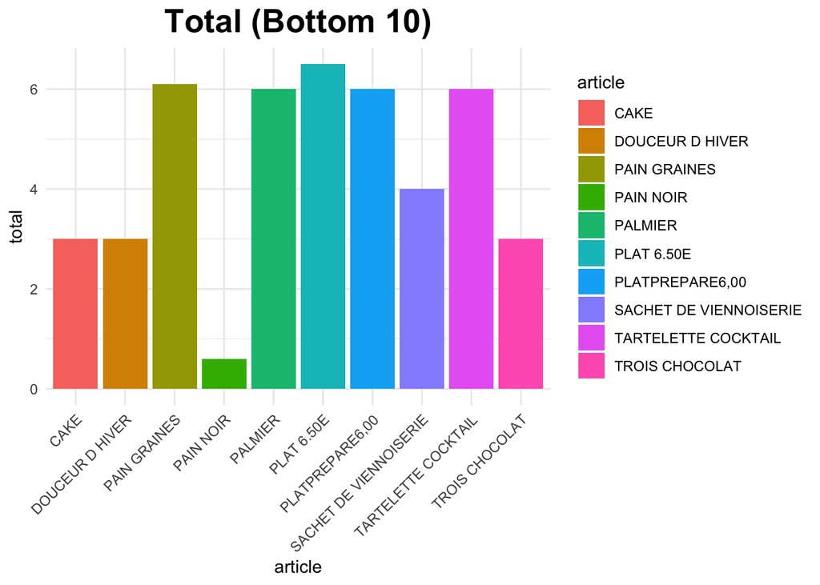

```r
ggplot(bottom10, aes(article, total, fill = article)) + geom_bar(stat = "Identity") + theme_minimal() + theme(axis.text.x = element_text(angle = 45, vjust = 1, hjust = 1)) + labs(title = "Total (Bottom 10)") + theme(plot.title = element_text(size = 20, face = "bold", hjust = 0.5))
```

What is the revenue growth?

```r
bakery_jan_sept <- filter(bakery, month %in% c("1","2","3","4","5","6","7","8","9")) #Choosing months January-September because 2022 only goes up to September
bakery_jan_sept <- filter(bakery_jan_sept, year == "2021")
rev2021 <- sum(bakery_jan_sept[bakery_jan_sept$year == "2021", "total"], na.rm = TRUE)
rev2021
```

```
## [1] 0
```

2022 revenue

```r
bakery2022 <- filter(bakery, year == "2022")
rev2022 <- sum(bakery2022[bakery2022$year == "2022", "total"], na.rm = TRUE)
rev2022
```

```
## [1] 256627.9
```

Calculating revenue growth

```r
revenue_growth <- ((rev2022 - rev2021) / rev2021) * 100
revenue_growth
```

```
## [1] Inf
```

```r
product_revenue <- bakery %>%
  group_by(article) %>%
  summarise(Total_Revenue = sum(total))
product_revenue
```

| article | Total_Revenue |
| --- | --- |
| 12 MACARON | 700.00 |
| ARMORICAIN | 7.50 |
| BAGUETTE | 20578.20 |
| BAGUETTE APERO | 310.50 |
| BAGUETTE GRAINE | 2481.20 |
| BANETTE | 24704.30 |
| BANETTINE | 1960.20 |
| BOISSON 33CL | 2832.00 |
| BOTTEREAU | 194.50 |
| BOULE 200G | 3512.15 |

[output cut: 137 more lines]